# Steak preferences in the USA

Summary Report For the **Mountain** Region

Author : Neelam Nakadi, Statistician

Friday, March 05, 2021

## Background

In May 2014, Walt Hickey at [538.com](http://fivethirtyeight.com/) published an article entitled [“How Americans Like Their Steak”](https://fivethirtyeight.com/features/how-americans-like-their-steak/). This article utilized survey data collected from 550 people which asked questions related to various risky activities, such as whether they speed in traffic, if they smoke or go skydiving, and if they prefer a riskier lottery. The survey also asked if they eat steak and if so, how they prefer their steak.

## Purpose

The “steak survey” dataset that was used for the [“How Americans Like Their Steak”](https://fivethirtyeight.com/features/how-americans-like-their-steak/) article, is available through the R package [`fivethirtyeight`](https://cran.r-%20project.org/web/packages/fivethirtyeight/index.html). Using this dataset, this article summarizes the steak preferences for the **Mountain** Region of the United States by gender.

For our summary presented here, a subset of the original steak survey was extracted to only include responses with no missing data and only included respondents from the **Mountain** region of the US. The data subset used for our summary had 24 respondents.

## Demographic Summary Tables

The age categories of the 24 survey respondents were:

```r
# create table of the age categories
tb <- sdat %>%
  select(age) %>%
  table() %>%
  prop.table()*100

# convert table to data frame
dt <- as.data.frame(tb)

# use kable from knitr package to make table
# and use kable styling from kableExtra package
knitr::kable(dt, format="html",
             col.names=c("Ages","%"),
             digits=2,
             caption="Ages of Survey Respondents") %>%
  kableExtra::kable_styling(bootstrap_options ="striped",
                            full_width=FALSE)
```

Ages of Survey Respondents

| Ages | % |
| --- | --- |
| 18-29 | 16.67 |
| 30-44 | 29.17 |
| 45-60 | 37.50 |
| > 60 | 16.67 |

The education levels of the 24 survey respondents were:

```r
# repeat for education
tb <-sdat %>%
  select(educ) %>%
  table() %>%
  prop.table()*100

dt <-as.data.frame(tb)

knitr::kable(dt, format="html",
             col.names=c("Education","%"),
             digits=2,
             caption="Education of Survey Respondents") %>%
  kableExtra::kable_styling(bootstrap_options = "striped",
                            full_width=FALSE)
```

Education of Survey Respondents

| Education | % |
| --- | --- |
| Less than high school degree | 0.00 |
| High school degree | 4.17 |
| Some college or Associate degree | 41.67 |
| Bachelor degree | 33.33 |
| Graduate degree | 20.83 |

The income levels of the 24 survey respondents were:

```r
# repeat for household income
tb <-sdat %>%
  select(hhold_income) %>%
  table() %>%
  prop.table()*100

dt <-as.data.frame(tb)

knitr::kable(dt, format="html",
             col.names=c("Income","%"),
             digits=2,
             caption="Income of Survey Respondents") %>%
  kableExtra::kable_styling(bootstrap_options = "striped",
                            full_width=FALSE)
```

Income of Survey Respondents

| Income | % |
| --- | --- |
| $0 - $24,999 | 8.33 |
| $25,000 - $49,999 | 16.67 |
| $50,000 - $99,999 | 50.00 |
| $100,000 - $149,999 | 12.50 |
| $150,000+ | 12.50 |
| TRUE | 0.00 |

## *OPTIONAL* Demographics of Survey Respondents in a Merged Table

This section is provided as an example of how to merge the three demographic summary tables for the 24 survey respondents above into a single merged table.

```r
# create table summary for ages
tb1 <-sdat %>%
  select(age) %>%
  table() %>%
  prop.table()*100

# create table summary for education
tb2 <-sdat %>%
  select(educ) %>%
  table() %>%
  prop.table()*100

# create table summary for income
tb3 <-sdat %>%
  select(hhold_income) %>%
  table() %>%
  prop.table()*100

# convert all tables to data frames
tb1df <-as.data.frame(tb1)
tb2df <-as.data.frame(tb2)
tb3df <-as.data.frame(tb3)

# merge 1st 2 data frames together
mtb <-merge(data.frame(tb1df, row.names = NULL),
            data.frame(tb2df, row.names = NULL),
            by=0, all=TRUE)[-1]
# merge result with 3rd data frame
mtb2 <-merge(data.frame(mtb, row.names = NULL),
             data.frame(tb3df, row.names = NULL),
             by=0, all=TRUE)[-1]

# use the final data frame
# make into a table with kable
# add styling with kableExtra
# add header with labels spanning 2 columns each
mtb2 %>%
 knitr::kable(format="html",
              col.names=c("Category","%","Category","%","Category","%"),
              digits=2,
              caption="Demographics of Survey Respondents") %>%
  kableExtra::kable_styling(c("striped","bordered"),
                            full_width=FALSE) %>%
  add_header_above(c("Ages"=2,"Education"=2,"Income"=2))
```

Demographics of Survey Respondents

| Ages Category | Ages % | Education Category | Education % | Income Category | Income % |
| --- | --- | --- | --- | --- | --- |
| 18-29 | 16.67 | Less than high school degree | 0.00 | $0 - $24,999 | 8.33 |
| 30-44 | 29.17 | High school degree | 4.17 | $25,000 - $49,999 | 16.67 |
| 45-60 | 37.50 | Some college or Associate degree | 41.67 | $50,000 - $99,999 | 50.00 |
| > 60 | 16.67 | Bachelor degree | 33.33 | $100,000 - $149,999 | 12.50 |
|  |  | Graduate degree | 20.83 | $150,000+ | 12.50 |
|  |  |  |  | TRUE | 0.00 |

## Steak Preparation Preference by Gender

Finally, here is a breakdown of the 24 survey respondents for the **Mountain** region of the US on how they prefer their steak to be prepared by gender.

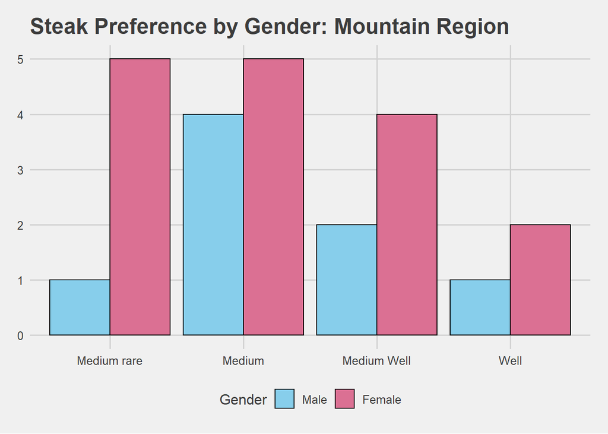

```r
ggplot(sdat, aes(x = steak_prep, fill = female)) +
  geom_bar(position="dodge",colour="black") +
  ggtitle(paste0("Steak Preference by Gender: ",
          "Mountain"," Region")) +
  xlab("Steak Preparation Preference") +
  ylab("Number of Respondents") +
  scale_fill_manual(values=c("skyblue","palevioletred"),
                    name="Gender",
                    breaks=c(FALSE,TRUE),
                    labels=c("Male", "Female")) +
  theme_fivethirtyeight()
```